# Comparison of methods to enforce sequence of layers in the problem of OCT segmentation

The porpose of this document is to compare the results of different methods that icorporate in predicting boundries of layers in OCT scan the fact that they always appear in a certain sequence.

In the document 3 different model are used:

- U-net with convolutional layers at the lowest level with one-hot encoded labels later referenced as convolutional model,
- U-net with convolutional layers at the lowest level with labels as continues values in range [0.1, 0.9] later referenced as regression model,
- U-net with vertical LSTM layer at the lowest level with one-hot encoded labels later referenced as recurrent model.

**Combining recurrent model with regression model is still in progress.**

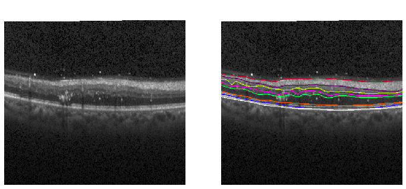

*Figure 1. Raw OCT scan and scan with visualised layers boundries.*

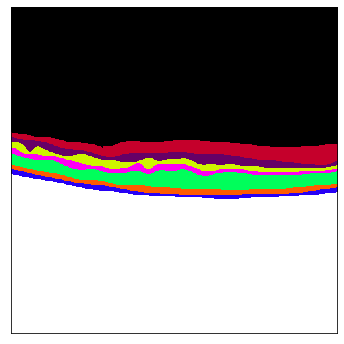

*Figure 2. Image used as target during training.*

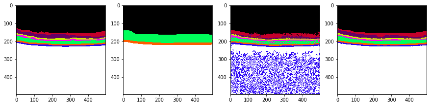

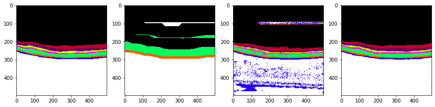

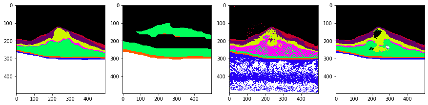

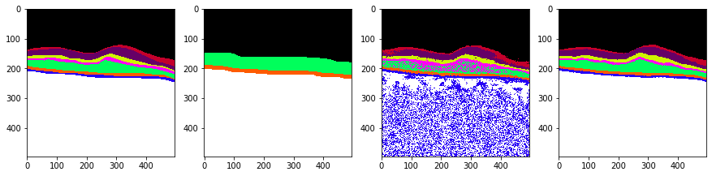

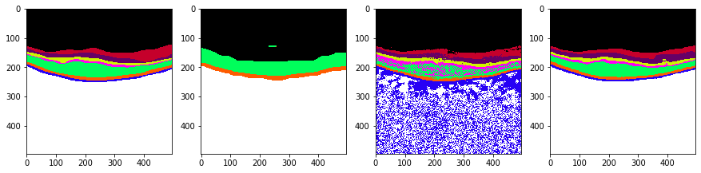

*Figure 3. Results of algorithms on test images.*

## Values of standard evaluation metrics

Table 1. presents value of 2 common metrics for regression model and recurrent model. First metric is an mean difference between borders of layers in the target and the borders predicted by the model.

In order to compute an border from model output (where whole image is classified) first Sobel filter is used to detect the edge. Then for each layer the image is treaded as a graph where every pixel is a node with 3 edges connected to pixels on the right, top-right and bottom-right. Additionally for algorithm to work correctly 2 artificial nodes are added. One connected to all pixels in the first column and one connected to all in the last column. Then we can define problem as finding shortest path from one artificial node to the other. Dijkstra algorithm is used to find the shortest path and cost of a edge is lowered if either origin or destination node (pixel) belongs to the layer for which boundry is created.

The second metric used is standard metric used in segmentation that is intersection over union.

*Table 1. Results of common metrics for 2 best models.*

|  | Regression model | Recurrent model |
| --- | --- | --- |
| Mean border distance | 11.460660 | 2.172127 |
| Mean intersection over union | 0.524967 | 0.948676 |